# EDS 231: Assignment 1

Scout Leonard

4/10/2022

# Objective

In this first assignment for EDS231: text and sentiment analysis for environmental data science, I am applying skills learned in lab to pull data from the New York Times (NYT) database via thier API, then running some basic string manipulations and creating some basic plots based on a topic of interest from NYT articles. I have chosen to analyze NYT documetns which utilize the word “honeybee.”

# Load Libraries

```
## here() starts at /Users/scoutleonard/Documents/school/MEDS/term_4/eds231/eds231
```

# Assignment 1 Responses

## Part 1

**Create a free New York Times account (https://developer.nytimes.com/get-started)**

Done! I have my key saved in a safe place (in addition to the place where it appears in my code below, haha!)

## Part 2

**Pick an interesting environmental key word(s) and use the jsonlite package to query the API. Pick something high profile enough and over a large enough time frame that your query yields enough articles for an interesting examination.**

I chose the keyword, “hoenybee,” and used data starting in 2017 (5 years of data) until today.

In the code chunk below, I set my search parameters and call data from the NYT API using my key, so that I can pull all the publications from these dates with my environmental key word.

The code will return the URL by search parameters build.

```r
#set search parameters
term <- "honeybee" # Need to use + to string together separate words
begin_date <- "20170101"
end_date <- "20220410"
key <- "CW2nwn63au0uAelc9XjRMGfQ1XZ2Vpo9"

#base url using our start and end dates and key term
baseurl <- paste0("http://api.nytimes.com/svc/search/v2/articlesearch.json?q=",term,
                  "&begin_date=",begin_date,"&end_date=",end_date,
                  "&facet_filter=true&api-key=", key, sep="")

#check: return base url
baseurl
```

```
## [1] "http://api.nytimes.com/svc/search/v2/articlesearch.json?q=honeybee&begin_date=20170101&end_date=20220410&facet_filter=true&api-key=CW2nwn63au0uAelc9XjRMGfQ1XZ2Vpo9"
```

## Part 3

**Recreate the publications per day and word frequency plots using the first paragraph**

[output not shown]

[output not shown]

[output not shown]

[output not shown]

[output not shown]

[output not shown]

[output not shown]

[output not shown]

[output not shown]

[output not shown]

[output not shown]

[output not shown]

[output not shown]

[output not shown]

[output not shown]

[output not shown]

[output not shown]

[output not shown]

```
## [1] "data.frame"
```

### Publications Per Day Plot

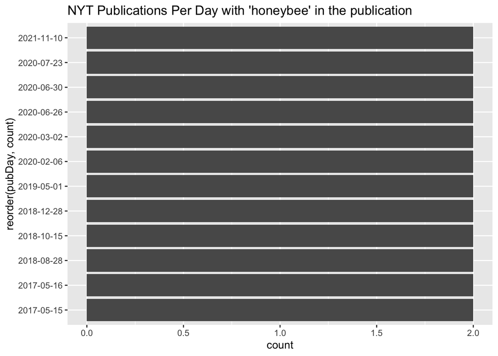

The code chunk below shows the frequency of the use of my environmental key word, ‘honeybee,’ with the dates on the y axis showing the date for which the corresponding x axis value, a frequncy of mentions per day, corresponds to.

```r
nytDat %>%
  mutate(pubDay = gsub("T.*",
                       "",
                       response.docs.pub_date)) %>%
  group_by(pubDay) %>%
  summarise(count=n()) %>%
  filter(count >= 2) %>%
  ggplot() +
  geom_bar(aes(x=reorder(pubDay, count),
               y=count),
           stat="identity") +
  coord_flip() +
  labs(title = "NYT Publications Per Day with 'honeybee' in the publication")
```

### Word Frequency Plot

```r
#check that this returns the lead paragraph,ie returns response.doc.lead.paragraph
paragraph <- names(nytDat)[6] #The 6th column, "response.doc.lead_paragraph", is the one we want here.

tokenized <- nytDat %>%
  unnest_tokens(word, paragraph)
```

```r
data(stop_words)

tokenized <- tokenized %>%
  anti_join(stop_words) #removes the stop words
```

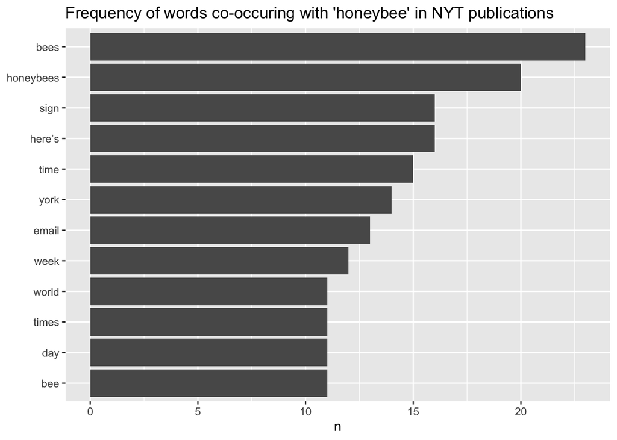

A frequency word plot of the use of ‘honeybee’ in New York Times publications. No processing of tokenized data has yet occured in for the word data, except for removing stop words with the R dataset ‘stop_words’.

```r
tokenized %>%
  count(word, sort = TRUE) %>%
  filter(n > 10) %>%
  mutate(word = reorder(word, n)) %>%
  ggplot(aes(n, word)) +
  geom_col() +
  labs(y = NULL,
       title = "Frequency of words co-occuring with 'honeybee' in NYT publications")
```

*Make some (at least 3) transformations to the corpus (add stopword(s), stem a key term and its variants, remove numbers)*

[output not shown]

[output cut: 1216 more lines]

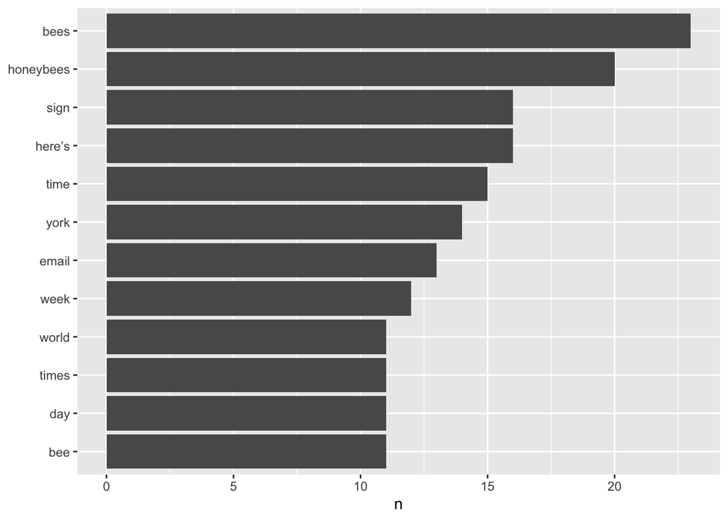

```r
#remove numbers
clean_tokens <- str_remove_all(tokenized$word, "[:digit:]")

#removes appostrophes
clean_tokens <- gsub("’s", '', clean_tokens)

#add stopwords
#NOTE! this is not working as i would expect rn
clean_tokens <- str_remove_all(clean_tokens, "ago")
clean_tokens <- str_remove_all(clean_tokens, "nytimes.com")
clean_tokens <- str_remove_all(clean_tokens, "york")
clean_tokens <- str_remove_all(clean_tokens, "it's")

#stem a key term
clean_tokens <- str_replace_all(tokenized$word," apis ","honeybee") #stem bee words
clean_tokens <- str_replace_all(tokenized$word,"honeybee*","honeybee")
clean_tokens <- str_replace_all(tokenized$word," bee ","honeybee")
clean_tokens <- str_replace_all(tokenized$word," bees ","honeybee")

tokenized$clean <- clean_tokens

#remove the empty strings
tib <-subset(tokenized, clean != "")

#reassign
tokenized <- tib

#try again
tokenized %>%
  count(clean, sort = TRUE) %>%
  filter(n > 10) %>% #illegible with all the words displayed
  mutate(clean = reorder(clean, n)) %>%
  ggplot(aes(n, clean)) +
  geom_col() +
  labs(y = NULL)
```

## Part 4

**Recreate the publications per day and word frequency plots using the headlines variable (response.docs.headline.main). Compare the distributions of word frequencies between the first paragraph and headlines. Do you see any difference?**

### Publications Per Day Plot

*NOTE: I am not sure how to specify I want headlines here*

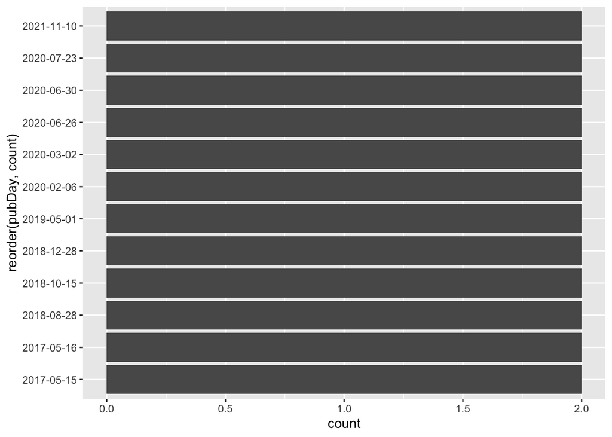

```r
nytDat %>%
  mutate(pubDay=gsub("T.*","",response.docs.pub_date)) %>%
  group_by(pubDay) %>%
  summarise(count=n()) %>%
  filter(count >= 2) %>%
  ggplot() +
  geom_bar(aes(x=reorder(pubDay, count), y=count), stat="identity") + coord_flip()
```

### Word frequency plot

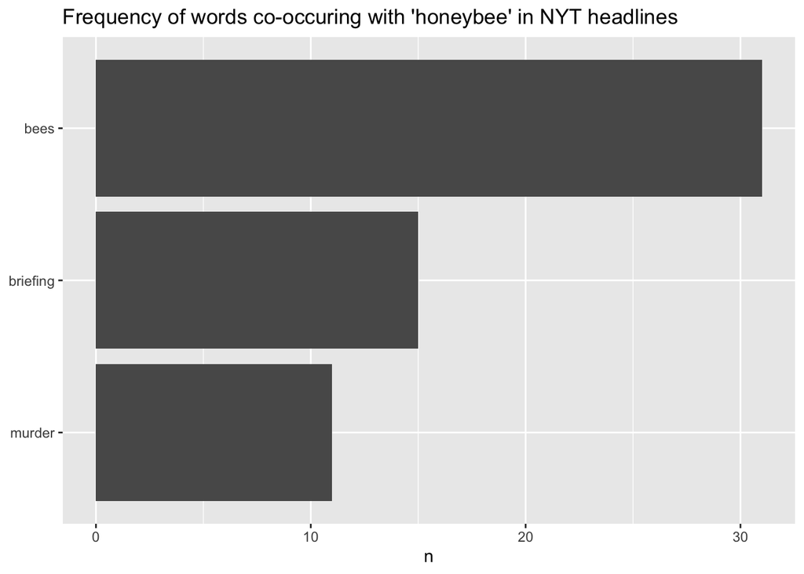

```r
#check that this returns the lead paragraph,ie returns response.doc.lead.paragraph
headline <- names(nytDat)[21] #The 6th column, "response.doc.lead_main", is the one we want here.

headlines_tokenized <- nytDat %>%
  unnest_tokens(word, headline)

data(stop_words)

headlines_tokenized <- headlines_tokenized %>%
  anti_join(stop_words) #removes the stop words
headlines_tokenized %>%
  count(word, sort = TRUE) %>%
  filter(n > 10) %>%
  mutate(word = reorder(word, n)) %>%
  ggplot(aes(n, word)) +
  geom_col() +
  labs(y = NULL,
       title = "Frequency of words co-occuring with 'honeybee' in NYT headlines")
```

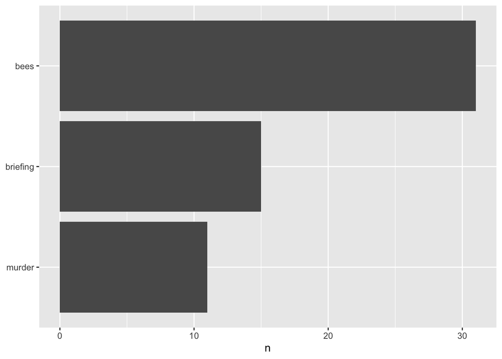

```r
#remove numbers
clean_headline_tokens <- str_remove_all(headlines_tokenized$word, "[:digit:]")

#removes appostrophes
clean_headline_tokens <- gsub("’s", '', clean_headline_tokens)

#add stopwords
#NOTE! this is not working as i would expect rn
clean_headline_tokens <- str_remove_all(clean_headline_tokens, "ago")
clean_headline_tokens <- str_remove_all(clean_headline_tokens, "nytimes.com")
clean_headline_tokens <- str_remove_all(clean_headline_tokens, "york")
clean_headline_tokens <- str_remove_all(clean_headline_tokens, "it's")

#stem a key term
clean_headline_tokens <- str_replace_all(headlines_tokenized$word," apis ","honeybee") #stem bee words
clean_headline_tokens <- str_replace_all(headlines_tokenized$word,"honeybee*","honeybee")
clean_headline_tokens <- str_replace_all(headlines_tokenized$word, " bee ","honeybee")
clean_headline_tokens <- str_replace_all(headlines_tokenized$word," bees ","honeybee")

headlines_tokenized$clean <- clean_headline_tokens

#remove the empty strings
tib <-subset(headlines_tokenized, clean != "")

#reassign
headlines_tokenized <- tib

#try again
headlines_tokenized %>%
  count(clean, sort = TRUE) %>%
  filter(n > 10) %>% #illegible with all the words displayed
  mutate(clean = reorder(clean, n)) %>%
  ggplot(aes(n, clean)) +
  geom_col() +
  labs(y = NULL)
```